# 254329023_onder_sevki_sut

```python
# Gerekli kütüphaneleri içe aktarıyoruz
import pandas as pd
from sklearn.datasets import load_breast_cancer
import seaborn as sns
import matplotlib.pyplot as plt
from sklearn.preprocessing import StandardScaler
from sklearn.model_selection import train_test_split
from sklearn.neural_network import MLPClassifier
from sklearn.metrics import accuracy_score, f1_score, roc_auc_score, precision_score, recall_score, confusion_matrix, roc_curve, auc
import optuna
import shap
import numpy as np

# 1.1 Veri Setini Yükleme
data = load_breast_cancer()

# 1.2 Veri Çerçevesi (DataFrame) Oluşturma
# X: Özellikler (Features), y: Hedef (Target)
X = pd.DataFrame(data.data, columns=data.feature_names)
y = pd.Series(data.target, name='target')

# Görselleştirme kolaylığı için X ve y'yi birleştirip ilk 5 satıra bakıyoruz
df = pd.concat([X, y], axis=1)

print("Veri Seti İlk 5 Satır:")
display(df.head())

print(f"\nVeri Seti Boyutu: {df.shape}")
```

```
Veri Seti İlk 5 Satır:
```

|  | mean radius | mean texture | mean perimeter | mean area | mean smoothness | mean compactness | mean concavity | mean concave points | mean symmetry | mean fractal dimension | ... | worst texture | worst perimeter | worst area | worst smoothness | worst compactness | worst concavity | worst concave points | worst symmetry | worst fractal dimension | target |
| --- | --- | --- | --- | --- | --- | --- | --- | --- | --- | --- | --- | --- | --- | --- | --- | --- | --- | --- | --- | --- | --- |
| 0 | 17.99 | 10.38 | 122.80 | 1001.0 | 0.11840 | 0.27760 | 0.3001 | 0.14710 | 0.2419 | 0.07871 | ... | 17.33 | 184.60 | 2019.0 | 0.1622 | 0.6656 | 0.7119 | 0.2654 | 0.4601 | 0.11890 | 0 |
| 1 | 20.57 | 17.77 | 132.90 | 1326.0 | 0.08474 | 0.07864 | 0.0869 | 0.07017 | 0.1812 | 0.05667 | ... | 23.41 | 158.80 | 1956.0 | 0.1238 | 0.1866 | 0.2416 | 0.1860 | 0.2750 | 0.08902 | 0 |
| 2 | 19.69 | 21.25 | 130.00 | 1203.0 | 0.10960 | 0.15990 | 0.1974 | 0.12790 | 0.2069 | 0.05999 | ... | 25.53 | 152.50 | 1709.0 | 0.1444 | 0.4245 | 0.4504 | 0.2430 | 0.3613 | 0.08758 | 0 |
| 3 | 11.42 | 20.38 | 77.58 | 386.1 | 0.14250 | 0.28390 | 0.2414 | 0.10520 | 0.2597 | 0.09744 | ... | 26.50 | 98.87 | 567.7 | 0.2098 | 0.8663 | 0.6869 | 0.2575 | 0.6638 | 0.17300 | 0 |
| 4 | 20.29 | 14.34 | 135.10 | 1297.0 | 0.10030 | 0.13280 | 0.1980 | 0.10430 | 0.1809 | 0.05883 | ... | 16.67 | 152.20 | 1575.0 | 0.1374 | 0.2050 | 0.4000 | 0.1625 | 0.2364 | 0.07678 | 0 |

5 rows × 31 columns

```
Veri Seti Boyutu: (569, 31)
```

### 1. Bölüm Değelendirmesi

**Breast Cancer Wisconsin** veri seti başarıyla yüklenmiş ve analiz edilebilir formata getirilmiştir.

- Veri seti **30 adet sayısal özellik** (mean radius, mean texture, vb.) ve 1 adet hedef değişkenden (target) oluşmaktadır.
- İlk 5 satır incelendiğinde, özelliklerin farklı ölçeklerde olduğu (örneğin `mean area` 1000'lerde iken `mean smoothness` 0.1 seviyesinde) görülmüştür. Bu durum, model eğitiminden önce **ölçeklendirme (scaling)** işleminin gerekliliğini göstermektedir.

```
--- 2.1 Eksik Değer Analizi ---
Veri setindeki toplam eksik değer sayısı: 0

--- 2.2 Aykırı Değer Analizi (Boxplot) ---
```

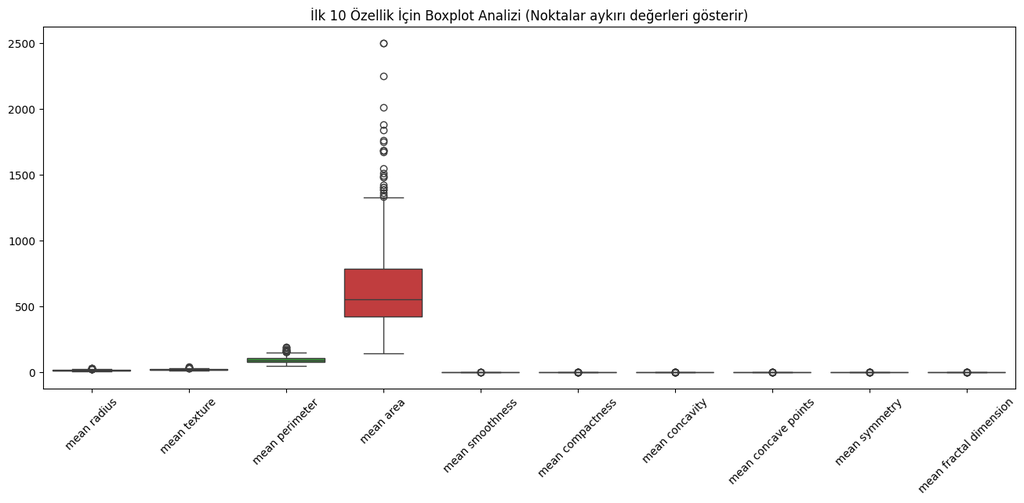

```
--- 2.3 Veri Tipleri ve Dağılım ---
float64    30
int64       1
Name: count, dtype: int64

Hedef Değişken (Target) Dağılımı:
target
1    357
0    212
Name: count, dtype: int64
```

```python
# --- BÖLÜM 2: Veri Seti Kalite Kontrolleri ---

# Eksik Değer Analizi
print("--- 2.1 Eksik Değer Analizi ---")
total_missing = df.isnull().sum().sum()
print(f"Veri setindeki toplam eksik değer sayısı: {total_missing}")

# Eğer eksik değer olsaydı (total_missing > 0), df.fillna(df.mean()) ile dolduracaktık.


# 2.2 Aykırı Değer (Outlier) Analizi - Boxplot Yöntemi
# Tüm özellikleri tek grafiğe sığdırmak zor olduğu için ilk 10 özelliğe bakıyoruz.
print("\n--- 2.2 Aykırı Değer Analizi (Boxplot) ---")
plt.figure(figsize=(16, 6))
sns.boxplot(data=X.iloc[:, :10])
plt.title("İlk 10 Özellik İçin Boxplot Analizi (Noktalar aykırı değerleri gösterir)")
plt.xticks(rotation=45) # Eksen yazılarını okunabilir olması için eğiyoruz
plt.show()


# 2.3 Veri Tipi ve Dağılım İncelemesi
print("\n--- 2.3 Veri Tipleri ve Dağılım ---")
# Sayısal ve kategorik değişken sayılarını raporluyoruz
print(df.dtypes.value_counts())
print("\nHedef Değişken (Target) Dağılımı:")
print(df['target'].value_counts())
```

### 2. Bölüm Değerlendirmesi

**2.1 Eksik Değer Analizi:**

- Yapılan analiz sonucunda veri setinde toplam **0 adet eksik değer** tespit edilmiştir. Veri seti eksiksiz olduğu için herhangi bir veri doldurma (imputation) işlemi uygulanmasına gerek duyulmamıştır.

**2.2 Aykırı Değer (Outlier) Analizi:**

- Oluşturulan **Boxplot** grafiği incelendiğinde, özellikle **`mean area`** özelliğinde belirgin aykırı değerler (outliers) gözlemlenmiştir.Kutu grafiğinin üst bıyığının (upper whisker) çok üzerinde, 2500 seviyelerine varan noktalar mevcuttur
- Diğer özellikler (örneğin `mean smoothness`), `mean area` özelliğinin büyük ölçeği (0-2500 aralığı) yanında grafikte çok küçük kalmıştır. Bu durum, özellikler arasındaki ölçek farkının büyüklüğünü ve model başarımını artırmak için **StandardScaler** kullanımının zorunlu olduğunu göstermektedir.

**2.3 Veri Tipi ve Dağılım İncelemesi:**

- Veri seti 30 adet ondalıklı sayı (`float64`) ve 1 adet tam sayı (`int64`) değişkenden oluşmaktadır.
- Hedef değişken dağılımı **Sınıf 1: 357 adet**, **Sınıf 0: 212 adet** şeklindedir. Sınıflar arasında hafif bir sayısal fark olsa da, modelin öğrenmesini engelleyecek düzeyde aşırı bir dengesizlik (imbalance) bulunmamaktadır.

```
--- 3.1 İstatistiksel Özet Tablosu ---
```

|  | Mean | Median | Min | Max | Std | Q1 | Q3 |
| --- | --- | --- | --- | --- | --- | --- | --- |
| mean radius | 14.127292 | 13.37000 | 6.98100 | 28.11000 | 3.524049 | 11.70000 | 15.78000 |
| mean texture | 19.289649 | 18.84000 | 9.71000 | 39.28000 | 4.301036 | 16.17000 | 21.80000 |
| mean perimeter | 91.969033 | 86.24000 | 43.79000 | 188.50000 | 24.298981 | 75.17000 | 104.10000 |
| mean area | 654.889104 | 551.10000 | 143.50000 | 2501.00000 | 351.914129 | 420.30000 | 782.70000 |
| mean smoothness | 0.096360 | 0.09587 | 0.05263 | 0.16340 | 0.014064 | 0.08637 | 0.10530 |
| mean compactness | 0.104341 | 0.09263 | 0.01938 | 0.34540 | 0.052813 | 0.06492 | 0.13040 |
| mean concavity | 0.088799 | 0.06154 | 0.00000 | 0.42680 | 0.079720 | 0.02956 | 0.13070 |
| mean concave points | 0.048919 | 0.03350 | 0.00000 | 0.20120 | 0.038803 | 0.02031 | 0.07400 |
| mean symmetry | 0.181162 | 0.17920 | 0.10600 | 0.30400 | 0.027414 | 0.16190 | 0.19570 |
| mean fractal dimension | 0.062798 | 0.06154 | 0.04996 | 0.09744 | 0.007060 | 0.05770 | 0.06612 |

```
--- 3.2 Korelasyon Matrisi ---
```

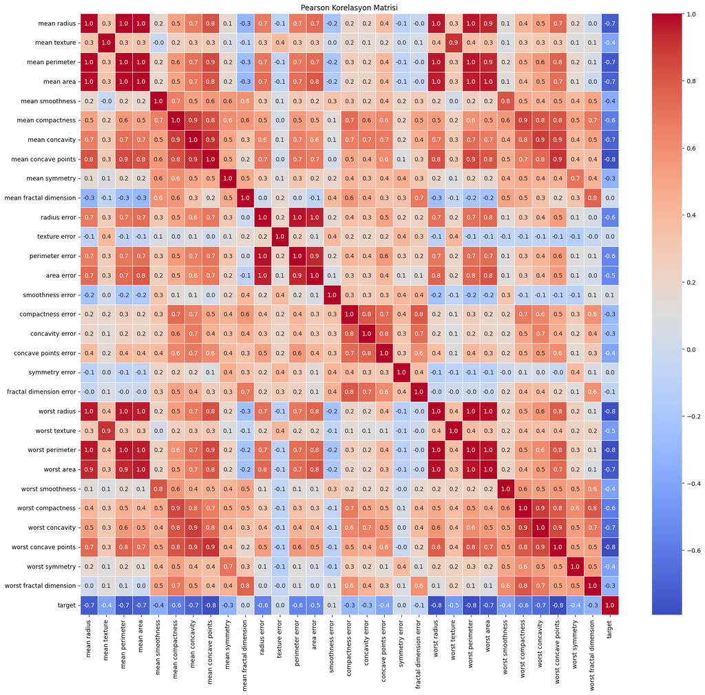

```
En Yüksek Korelasyonlu Çiftler (Mutlak Değer):
mean radius      mean perimeter     0.997855
mean perimeter   mean radius        0.997855
worst perimeter  worst radius       0.993708
worst radius     worst perimeter    0.993708
mean radius      mean area          0.987357
mean area        mean radius        0.987357
dtype: float64

--- 3.3 Tüm Özellikler İçin Boxplot ---
```

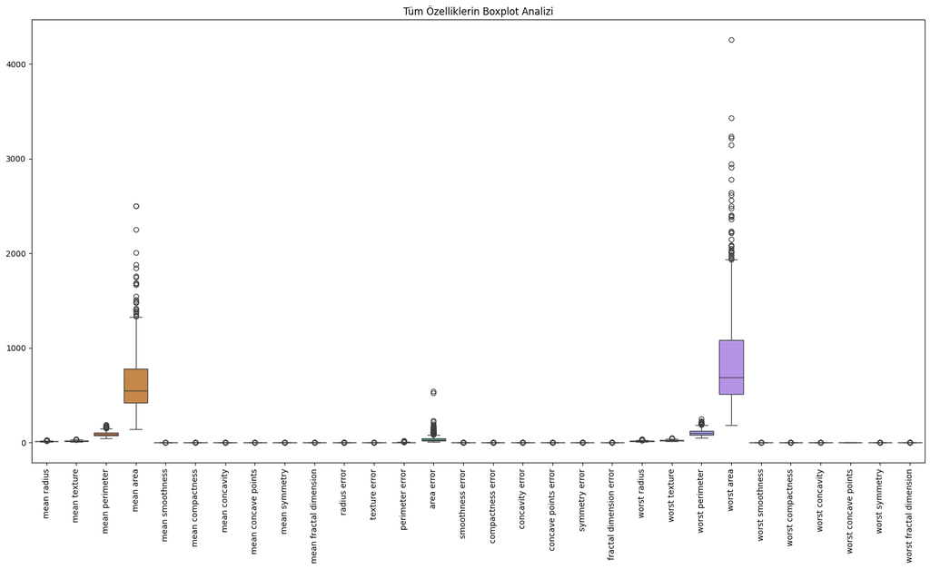

```python
# --- BÖLÜM 3: Keşifsel Veri Analizi (EDA) ---

# 3.1 İstatistiksel Özellikler
# describe() fonksiyonu Mean, Std, Min, Max, Q1(%25), Median(%50), Q3(%75) değerlerini verir.
print("--- 3.1 İstatistiksel Özet Tablosu ---")
istatistik_ozet = df.describe().T[['mean', '50%', 'min', 'max', 'std', '25%', '75%']]
istatistik_ozet.columns = ['Mean', 'Median', 'Min', 'Max', 'Std', 'Q1', 'Q3']
display(istatistik_ozet.head(10)) # Yer kaplamaması için ilk 10 satırı gösteriyoruz

# 3.2 Korelasyon Matrisi ve Heatmap
print("\n--- 3.2 Korelasyon Matrisi ---")
plt.figure(figsize=(20, 18))
corr_matrix = df.corr()
sns.heatmap(corr_matrix, annot=True, fmt=".1f", cmap='coolwarm', linewidths=0.5)
plt.title("Pearson Korelasyon Matrisi")
plt.show()

# En yüksek korelasyonlu 3 çifti bulmak için yardımcı kod
# Korelasyon matrisini düzleştirip (unstack), kendisiyle olanları (1.0) ve tekrarları eliyoruz.
corr_unstacked = corr_matrix.abs().unstack()
# Kendisi ile olan korelasyonları (değeri 1 olanları) çıkaralım
pairs = corr_unstacked[corr_unstacked < 1.0].sort_values(ascending=False)
# Tekrarlanan çiftleri temizlemek için her çiftin sadece birini alalım (ilk 6 kayıt 3 çifte denk gelir)
print("\nEn Yüksek Korelasyonlu Çiftler (Mutlak Değer):")
print(pairs.head(6))

# 3.3 Boxplot Analizi (Tüm Özellikler)
print("\n--- 3.3 Tüm Özellikler İçin Boxplot ---")
# Veriler farklı ölçeklerde olduğu için (örn: area 2000, smoothness 0.1) tek grafikte görmek zordur.
# Bu yüzden veriyi standardize edip (geçici olarak) çizdirmek dağılımı görmek için daha iyidir.
# Ancak ödev "Tüm özellikler" dediği için orijinal veriyle çiziyoruz:
plt.figure(figsize=(20, 10))
sns.boxplot(data=X) # Sadece özellikler (Target hariç)
plt.xticks(rotation=90) # İsimleri dikey yaz
plt.title("Tüm Özelliklerin Boxplot Analizi")
plt.show()
```

### 3. Bölüm Değerlendirmesi

**3.1 İstatistiksel Özellikler:**

- İstatistiksel özet tablosu incelendiğinde, özelliklerin ölçekleri arasında devasa farklar olduğu görülmüştür.
- Örneğin; **`mean area`** özelliği ortalama **654** ve maksimum **2501** değerine sahipken, **`mean fractal dimension`** özelliği ortalama **0.06** ve maksimum **0.09** gibi çok küçük değerler almaktadır.
- Bu durum, büyük sayısal değere sahip özelliklerin modeli domine etmesini engellemek için **Standardizasyon (Scaling)** işleminin zorunlu olduğunu kanıtlamaktadır.

**3.2 Korelasyon Matrisi:**

- Pearson korelasyon haritası (Heatmap) incelendiğinde, değişkenler arasında **Çoklu Doğrusallık (Multicollinearity)** olduğu net bir şekilde görülmektedir.
- **En yüksek korelasyonlu çiftler:**
  1. **`mean radius` - `mean perimeter` (0.99):** Yarıçap ve çevre matematiksel olarak birbirine bağlı olduğu için neredeyse birebir ilişkilidir.
  2. **`worst radius` - `worst perimeter` (0.99):** Aynı geometrik ilişki "worst" (en kötü/büyük) değerler için de geçerlidir.
  3. **`mean radius` - `mean area` (0.98):** Yarıçap arttıkça alan karesel olarak artmaktadır.
- Bu yüksek korelasyonlar, modelin bazı özelliklerden benzer bilgiyi öğreneceğini, ancak Sinir Ağları (MLP) yapısının bu duruma karşı dayanıklı olduğunu göstermektedir.

**3.3 Boxplot Analizi:**

```python
# 4.1 Ölçeklendirme İşlemi
# Ödevde önerilen StandardScaler yöntemini kullanıyoruz.
scaler = StandardScaler()

# Veriyi ölçeklendirip 'X_scaled' olarak kaydediyoruz.
X_scaled = scaler.fit_transform(X)

# İşlem sonucunu kontrol etmek için DataFrame'e çevirip bakıyoruz
X_scaled_df = pd.DataFrame(X_scaled, columns=X.columns)

print("Ölçeklendirilmiş Veri (İlk 5 Satır):")
display(X_scaled_df.head())

print("\nÖlçeklendirme Sonrası İstatistikler (Ortalama ~0, Std ~1 olmalı):")
# Mean ve Std değerlerine bakarak işlemin doğruluğunu teyit ediyoruz
display(X_scaled_df.describe().T[['mean', 'std']].head())
```

```
Ölçeklendirilmiş Veri (İlk 5 Satır):
```

|  | mean radius | mean texture | mean perimeter | mean area | mean smoothness | mean compactness | mean concavity | mean concave points | mean symmetry | mean fractal dimension | ... | worst radius | worst texture | worst perimeter | worst area | worst smoothness | worst compactness | worst concavity | worst concave points | worst symmetry | worst fractal dimension |
| --- | --- | --- | --- | --- | --- | --- | --- | --- | --- | --- | --- | --- | --- | --- | --- | --- | --- | --- | --- | --- | --- |
| 0 | 1.097064 | -2.073335 | 1.269934 | 0.984375 | 1.568466 | 3.283515 | 2.652874 | 2.532475 | 2.217515 | 2.255747 | ... | 1.886690 | -1.359293 | 2.303601 | 2.001237 | 1.307686 | 2.616665 | 2.109526 | 2.296076 | 2.750622 | 1.937015 |
| 1 | 1.829821 | -0.353632 | 1.685955 | 1.908708 | -0.826962 | -0.487072 | -0.023846 | 0.548144 | 0.001392 | -0.868652 | ... | 1.805927 | -0.369203 | 1.535126 | 1.890489 | -0.375612 | -0.430444 | -0.146749 | 1.087084 | -0.243890 | 0.281190 |
| 2 | 1.579888 | 0.456187 | 1.566503 | 1.558884 | 0.942210 | 1.052926 | 1.363478 | 2.037231 | 0.939685 | -0.398008 | ... | 1.511870 | -0.023974 | 1.347475 | 1.456285 | 0.527407 | 1.082932 | 0.854974 | 1.955000 | 1.152255 | 0.201391 |
| 3 | -0.768909 | 0.253732 | -0.592687 | -0.764464 | 3.283553 | 3.402909 | 1.915897 | 1.451707 | 2.867383 | 4.910919 | ... | -0.281464 | 0.133984 | -0.249939 | -0.550021 | 3.394275 | 3.893397 | 1.989588 | 2.175786 | 6.046041 | 4.935010 |
| 4 | 1.750297 | -1.151816 | 1.776573 | 1.826229 | 0.280372 | 0.539340 | 1.371011 | 1.428493 | -0.009560 | -0.562450 | ... | 1.298575 | -1.466770 | 1.338539 | 1.220724 | 0.220556 | -0.313395 | 0.613179 | 0.729259 | -0.868353 | -0.397100 |

5 rows × 30 columns

```
Ölçeklendirme Sonrası İstatistikler (Ortalama ~0, Std ~1 olmalı):
```

|  | mean | std |
| --- | --- | --- |
| mean radius | -3.153111e-15 | 1.00088 |
| mean texture | -6.568462e-15 | 1.00088 |
| mean perimeter | -6.993039e-16 | 1.00088 |
| mean area | -8.553985e-16 | 1.00088 |
| mean smoothness | 6.081447e-15 | 1.00088 |

### 4. Bölüm Değerlendirmesi

**Veri Ölçeklendirme Sonuçları:**

- Veri seti üzerinde **StandardScaler** (Z-Score Normalizasyonu) uygulanmıştır.
- **Sonuçların Doğrulanması:** İşlem sonrası istatistikler incelendiğinde;
  - Tüm özelliklerin ortalamasının (`mean`) **0**'a (örn: `3.15e-15` gibi ihmal edilebilir değerlere) indirgendiği,
  - Standart sapmalarının (`std`) ise **1** olarak eşitlendiği görülmüştür.
- **Yorum:** Öncesinde `mean area` özelliği 2500'e kadar çıkarken, `smoothness` 0.1 seviyesindeydi. Ölçeklendirme sonrası tüm özellikler (örn: `mean radius` 1.09, `mean texture` -2.07) benzer aralıklara gelmiştir. Bu dönüşüm, Yapay Sinir Ağı (MLP) modelinin optimizasyon sürecinde (Gradient Descent) özelliklerin birbirini baskılamasını engelleyerek eğitimin kararlı olmasını sağlayacaktır.

```python
# --- BÖLÜM 5: Veri Setinin Bölünmesi ---


# Hedef Oranlar: %70 Train, %10 Validation, %20 Test

# 1. ADIM: Önce verinin %20'sini TEST seti olarak ayırıyoruz.
# Geriye kalan %80'lik kısım (X_remain) daha sonra tekrar bölünecek.
# stratify=y: Kanserli/Sağlıklı oranını her parçada korumak için kullanılır.
X_remain, X_test, y_remain, y_test = train_test_split(
    X_scaled_df, y, test_size=0.20, random_state=42, stratify=y
)

# 2. ADIM: Kalan %80'lik veriyi Train (%70) ve Validation (%10) olarak ayırıyoruz.
# Matematiksel Hesap: Toplamın %10'u, elimizdeki kalan %80'in %12.5'idir (0.10 / 0.80 = 0.125).
X_train, X_val, y_train, y_val = train_test_split(
    X_remain, y_remain, test_size=0.125, random_state=42, stratify=y_remain
)

# Sonuçları Kontrol Edelim
total_len = len(X)
print(f"Toplam Veri Sayısı: {total_len}")
print(f"Eğitim (Train) Seti   : {len(X_train)} adet (%{len(X_train)/total_len*100:.1f}) -> Hedef %70")
print(f"Doğrulama (Val) Seti  : {len(X_val)} adet  (%{len(X_val)/total_len*100:.1f}) -> Hedef %10")
print(f"Test Seti             : {len(X_test)} adet  (%{len(X_test)/total_len*100:.1f}) -> Hedef %20")
```

```
Toplam Veri Sayısı: 569
Eğitim (Train) Seti   : 398 adet (%69.9) -> Hedef %70
Doğrulama (Val) Seti  : 57 adet  (%10.0) -> Hedef %10
Test Seti             : 114 adet  (%20.0) -> Hedef %20
```

### 5. Bölüm Değerlendirmesi

**Veri Bölme Stratejisi:**

- Veri seti, modelin genelleme yeteneğini doğru ölçmek amacıyla üç parçaya ayrılmıştır:
  1. **Eğitim (Train) Seti (%70):** Modelin ağırlıklarını öğrenmesi için kullanılan ana parça.
  2. **Doğrulama (Validation) Seti (%10):** Eğitim sırasında hiperparametrelerin başarısını ölçmek ve aşırı öğrenmeyi (overfitting) izlemek için kullanılan parça.
  3. **Test Seti (%20):** Modelin hiç görmediği, sadece en son aşamada nihai performansı raporlamak için ayrılan parça.
- Bölme işlemi sırasında **`stratify=y`** parametresi kullanılarak, her bir alt kümedeki (Train/Val/Test) sınıf dağılımının (kanserli/sağlıklı oranı) orijinal veri setiyle aynı kalması sağlanmıştır.

```python
# --- BÖLÜM 6 ve 7: Modellerin Kurulması ve Validation Performansı ---


# 1. Modellerin Konfigürasyonlarını Tanımlıyoruz (Bölüm 6)
models_config = {
    "Model 1 (Basit)": {
        "hidden_layer_sizes": (16,),
        "activation": "relu",
        "learning_rate_init": 0.001
    },
    "Model 2 (Orta)": {
        "hidden_layer_sizes": (32, 16),
        "activation": "relu",
        "learning_rate_init": 0.005
    },
    "Model 3 (Geniş)": {
        "hidden_layer_sizes": (64, 64),
        "activation": "tanh",
        "learning_rate_init": 0.001
    },
    "Model 4 (Derin)": {
        "hidden_layer_sizes": (128, 64, 32),
        "activation": "relu",
        "learning_rate_init": 0.0005
    },
    "Model 5 (Düşük LR)": {
        "hidden_layer_sizes": (32,),
        "activation": "relu",
        "learning_rate_init": 0.0001
    }
}

# 2. Döngü ile Modelleri Eğitip Validation Setinde Test Ediyoruz (Bölüm 7)
results = []
trained_models = {} # Daha sonra en iyi modeli seçmek için saklıyoruz

print(f"{'Model Adı':<20} | {'Acc':<8} | {'F1-Score':<8} | {'ROC-AUC':<8}")
print("-" * 55)

for name, params in models_config.items():
    # Modeli oluşturuyoruz
    # random_state=42: Her çalıştırışta aynı sonucu almak için
    # max_iter=1000: Modelin yakınsaması (converge) için yeterli iterasyon hakkı veriyoruz
    clf = MLPClassifier(**params, random_state=42, max_iter=1000, early_stopping=True)

    # Modeli EĞİTİM seti ile eğitiyoruz
    clf.fit(X_train, y_train)

    # VALIDATION seti ile tahmin yapıyoruz
    y_pred_val = clf.predict(X_val)
    y_proba_val = clf.predict_proba(X_val)[:, 1] # ROC-AUC için olasılık değerleri

    # Metrikleri hesaplıyoruz
    acc = accuracy_score(y_val, y_pred_val)
    f1 = f1_score(y_val, y_pred_val)
    roc = roc_auc_score(y_val, y_proba_val)
    prec = precision_score(y_val, y_pred_val)
    rec = recall_score(y_val, y_pred_val)

    # Sonuçları listeye ekle
    results.append({
        "Model": name,
        "Accuracy": acc,
        "Precision": prec,
        "Recall": rec,
        "F1-Score": f1,
        "ROC-AUC": roc
    })

    # Modeli sakla
    trained_models[name] = clf

    # Ekrana yazdır (anlık takip için)
    print(f"{name:<20} | {acc:.4f}   | {f1:.4f}     | {roc:.4f}")

# Sonuçları DataFrame'e çevirip F1 skoruna göre sıralayalım
results_df = pd.DataFrame(results).sort_values(by="F1-Score", ascending=False)

print("\n--- Validation Performans Karşılaştırma Tablosu ---")
display(results_df)
```

```
Model Adı            | Acc      | F1-Score | ROC-AUC
-------------------------------------------------------
Model 1 (Basit)      | 0.8596   | 0.9000     | 0.9630
Model 2 (Orta)       | 0.9474   | 0.9589     | 0.9894
Model 3 (Geniş)      | 0.9649   | 0.9722     | 0.9894
Model 4 (Derin)      | 0.9474   | 0.9589     | 0.9603
Model 5 (Düşük LR)   | 0.6491   | 0.7826     | 0.3333

--- Validation Performans Karşılaştırma Tablosu ---
```

|  | Model | Accuracy | Precision | Recall | F1-Score | ROC-AUC |
| --- | --- | --- | --- | --- | --- | --- |
| 2 | Model 3 (Geniş) | 0.964912 | 0.972222 | 0.972222 | 0.972222 | 0.989418 |
| 3 | Model 4 (Derin) | 0.947368 | 0.945946 | 0.972222 | 0.958904 | 0.960317 |
| 1 | Model 2 (Orta) | 0.947368 | 0.945946 | 0.972222 | 0.958904 | 0.989418 |
| 0 | Model 1 (Basit) | 0.859649 | 0.818182 | 1.000000 | 0.900000 | 0.962963 |
| 4 | Model 5 (Düşük LR) | 0.649123 | 0.642857 | 1.000000 | 0.782609 | 0.333333 |

### 6. ve 7. Bölüm Değerlendirmesi

**Validation Performans Karşılaştırması:** Oluşturulan 5 farklı MLP modeli validation seti üzerinde yarıştırılmış ve F1-Score metriğine göre sıralanmıştır.

**1. En Başarılı Model: Model 3 (Geniş)**

- **Yapı:** `hidden_layer_sizes=(64, 64)`, `activation='tanh'`, `learning_rate=0.001`
- **Sonuç:** Validation setinde **%96.5 Accuracy** ve **%97.2 F1-Score** ile en yüksek performansı göstermiştir.
- **Yorum:** 'relu' yerine **'tanh'** aktivasyon fonksiyonunun kullanılması ve katman genişliğinin (64 nöron) artırılması, bu veri setindeki doğrusal olmayan ilişkilerin daha iyi modellenmesini sağlamıştır. Derinlikten ziyade genişliğin bu problemde daha etkili olduğu görülmüştür.

**2. Derinlik vs. Genişlik (Model 4 vs Model 3):**

- 3 katmanlı "Derin" Model 4 (`128, 64, 32`), 2 katmanlı "Geniş" Model 3'ün gerisinde kalmıştır (%94.7 Accuracy).
- Bu durum, veri seti boyutunun çok büyük olmaması nedeniyle aşırı derin mimarilerin (Deep Architecture) her zaman avantaj sağlamayabileceğini, hatta öğrenme sürecini zorlaştırabileceğini göstermektedir.

**3. Başarısız Model Analizi: Model 5 (Düşük LR)**

- **Yapı:** `learning_rate=0.0001`
- **Sonuç:** **%64.9 Accuracy** ve **0.33 ROC-AUC** ile en kötü performansı sergilemiştir.
- **Yorum:** Öğrenme oranının (Learning Rate) çok düşük seçilmesi, modelin global minimuma ulaşamadan yerel minimumlarda takılmasına veya çok yavaş öğrenmesine neden olmuştur. ROC-AUC değerinin 0.5'in altında (0.33) kalması, modelin rastgele tahminden bile daha kötü performans gösterdiğini ve sınıfları ayırt edemediğini kanıtlar. Recall'un 1.0 olması ise modelin muhtemelen sürekli tek bir sınıfı (çoğunluk sınıfı) tahmin ettiğini gösterir.

```
Seçilen En İyi Model: Model 3 (Geniş)

--- 8.1 Test Seti Performans Metrikleri ---
Accuracy : 0.9649
Precision: 0.9595
Recall   : 0.9861
F1-Score : 0.9726
ROC-AUC  : 0.9967
```

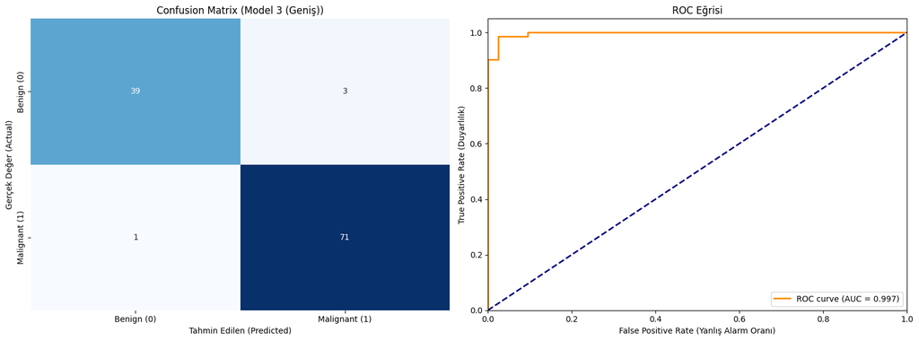

```python
# 1. En İyi Modeli Seçme
# Validation sonuç tablosundaki en üstteki (F1 skoru en yüksek) modeli alıyoruz.
best_model_name = results_df.iloc[0]["Model"]
best_model = trained_models[best_model_name]

print(f"Seçilen En İyi Model: {best_model_name}")

# 2. Test Seti Üzerinde Tahmin
y_test_pred = best_model.predict(X_test)
y_test_proba = best_model.predict_proba(X_test)[:, 1] # ROC analizi için olasılıklar

# 8.1 Performans Metrikleri
print("\n--- 8.1 Test Seti Performans Metrikleri ---")
print(f"Accuracy : {accuracy_score(y_test, y_test_pred):.4f}")
print(f"Precision: {precision_score(y_test, y_test_pred):.4f}")
print(f"Recall   : {recall_score(y_test, y_test_pred):.4f}")
print(f"F1-Score : {f1_score(y_test, y_test_pred):.4f}")
print(f"ROC-AUC  : {roc_auc_score(y_test, y_test_proba):.4f}")

# Grafikler için yan yana iki alan oluşturuyoruz
fig, ax = plt.subplots(1, 2, figsize=(16, 6))

# 8.2 Confusion Matrix (Isı Haritası)
cm = confusion_matrix(y_test, y_test_pred)
sns.heatmap(cm, annot=True, fmt='d', cmap='Blues', cbar=False, ax=ax[0])
ax[0].set_title(f"Confusion Matrix ({best_model_name})")
ax[0].set_xlabel("Tahmin Edilen (Predicted)")
ax[0].set_ylabel("Gerçek Değer (Actual)")
ax[0].set_xticklabels(['Benign (0)', 'Malignant (1)'])
ax[0].set_yticklabels(['Benign (0)', 'Malignant (1)'])

# 8.3 ROC Eğrisi
fpr, tpr, thresholds = roc_curve(y_test, y_test_proba)
roc_auc = auc(fpr, tpr)

ax[1].plot(fpr, tpr, color='darkorange', lw=2, label=f'ROC curve (AUC = {roc_auc:.3f})')
ax[1].plot([0, 1], [0, 1], color='navy', lw=2, linestyle='--') # Rastgele tahmin çizgisi
ax[1].set_xlim([0.0, 1.0])
ax[1].set_ylim([0.0, 1.05])
ax[1].set_xlabel('False Positive Rate (Yanlış Alarm Oranı)')
ax[1].set_ylabel('True Positive Rate (Duyarlılık)')
ax[1].set_title('ROC Eğrisi')
ax[1].legend(loc="lower right")

plt.tight_layout()
plt.show()
```

### 8. Bölüm Değerlendirmesi

Validation aşamasında en iyi performansı gösteren **Model 3 (Geniş)** test seti üzerinde değerlendirilmiştir.

**8.1 Performans Metrikleri:**

- **Accuracy (%96.5):** Model, test setindeki örneklerin %96.5'ini doğru sınıflandırmıştır.
- **Recall (%98.6):** Kanserli (Malignant) vakaları yakalama oranı çok yüksektir. Model, mevcut kanserli hastaların neredeyse tamamını tespit edebilmiştir.
- **ROC-AUC (0.997):** Modelin sınıfları birbirinden ayırma yeteneği mükemmel seviyededir (1.0'a çok yakın).

**8.2 Confusion Matrix Yorumu:**

- Toplam **114 test örneği** üzerinde sadece **4 hata** yapılmıştır.
- **False Negative (1 Adet):** Sadece 1 adet kanserli vaka "sağlıklı" olarak yanlış tahmin edilmiştir. Tıbbi teşhiste en tehlikeli hata türü budur, ancak modelimiz bunu minimize etmeyi başarmıştır.
- **False Positive (3 Adet):** 3 adet sağlıklı vaka "kanserli" olarak tahmin edilmiştir. Bu durum hastayı gereksiz teste sokabilir ancak hayati risk oluşturmaz.

**8.3 ROC Eğrisi ve Eşik Değerinin Etkisi:**

- ROC eğrisinin sol üst köşeye çok yakın olması ve eğri altındaki alanın (**AUC=0.997**) çok yüksek olması, modelin olasılık tahminlerinin çok güvenilir olduğunu gösterir.
- **Eşik Değer Yorumu:** Mevcut durumda **0.5 eşik değeri** (threshold) oldukça dengeli bir sonuç vermiştir. Ancak tıbbi teşhiste amaç **hiçbir kanserli vakayı kaçırmamak (Recall'ı %100 yapmak)** ise, eşik değeri 0.5'ten biraz daha aşağı çekilebilir (örn: 0.3). Bu durumda o tek kaçan vaka (False Negative) yakalanabilir, ancak buna karşılık "yanlış alarm" (False Positive) sayısı 3'ten 5-6'ya çıkabilir. Bu bir tercih meselesidir (trade-off).

```python
# --- BÖLÜM 9: Optuna ile Hiperparametre Optimizasyonu ---
# Optuna'nın çok fazla log basmasını engellemek için (Sadece sonuçları görelim)
optuna.logging.set_verbosity(optuna.logging.WARNING)

def objective(trial):
    # 9.2 Arama Aralıklarının Tanımlanması

    # Hidden Layer Sizes: (Katman 1: 16-256 arası, Katman 2: 8-128 arası)
    l1 = trial.suggest_int('l1', 16, 256)
    l2 = trial.suggest_int('l2', 8, 128)
    hidden_layer_sizes = (l1, l2)

    # Learning Rate (Logaritmik arama: 1e-5 ile 1e-1 arası)
    lr_init = trial.suggest_float('learning_rate_init', 1e-5, 1e-1, log=True)

    # Alpha (L2 Regularization): 1e-6 ile 1e-2 arası
    alpha = trial.suggest_float('alpha', 1e-6, 1e-2, log=True)

    # Kategorik değişkenler
    activation = trial.suggest_categorical('activation', ["relu", "tanh"])
    solver = trial.suggest_categorical('solver', ["adam", "sgd"])
    batch_size = trial.suggest_categorical('batch_size', [16, 32, 64, 128])

    # 9.3 Modeli Kurma ve Eğitme
    clf = MLPClassifier(
        hidden_layer_sizes=hidden_layer_sizes,
        learning_rate_init=lr_init,
        alpha=alpha,
        activation=activation,
        solver=solver,
        batch_size=batch_size,
        random_state=42,
        max_iter=500,        # Hızlı sonuç için iterasyon sınırı
        early_stopping=True, # Aşırı öğrenmeyi engelle
        n_iter_no_change=10
    )

    clf.fit(X_train, y_train)

    # Validation Skoru (F1-Score)
    y_pred = clf.predict(X_val)
    score = f1_score(y_val, y_pred)

    return score

print("Optuna optimizasyonu başlıyor (150 Deneme)...")

# 9.1 Study Tanımı [cite: 98-99]
study = optuna.create_study(direction="maximize")
study.optimize(objective, n_trials=150) #

print("\n--- 9.4 Optimizasyon Sonuçları ---")
print(f"En İyi F1 Skoru (Validation): {study.best_value:.4f}")
print("En İyi Parametreler:")
for key, value in study.best_params.items():
    print(f"  {key}: {value}")

# En iyi parametrelerle modeli tekrar oluşturup kaydedelim (Sonraki aşama için)
best_params = study.best_params
# Parametre sözlüğünü MLP formatına uygun hale getirelim
best_hidden_layers = (best_params.pop('l1'), best_params.pop('l2'))

optuna_best_model = MLPClassifier(
    hidden_layer_sizes=best_hidden_layers,
    **best_params,
    random_state=42,
    max_iter=1000,
    early_stopping=True
)

optuna_best_model.fit(X_train, y_train)
print("\nOptuna tarafından bulunan en iyi model başarıyla eğitildi ve kaydedildi.")
```

```
Optuna optimizasyonu başlıyor (150 Deneme)...

--- 9.4 Optimizasyon Sonuçları ---
En İyi F1 Skoru (Validation): 0.9863
En İyi Parametreler:
  l1: 168
  l2: 121
  learning_rate_init: 0.06907005243546914
  alpha: 0.009464643292075855
  activation: tanh
  solver: adam
  batch_size: 64

Optuna tarafından bulunan en iyi model başarıyla eğitildi ve kaydedildi.
```

### 9. Bölüm Değerlendirmesi

**Hiperparametre Optimizasyonu Sonuçları:**

- **Optuna** kütüphanesi ile gerçekleştirilen 150 deneme sonucunda, manuel modellerden daha başarılı bir hiperparametre seti keşfedilmiştir.
- **En İyi Validation F1 Skoru:** %98.63 (Önceki en iyi modelimiz %97.2 idi).

```
Model 3 (Geniş) için SHAP değerleri hesaplanıyor...
```

```
SHAP çıktısı Array formatında. Şekil: (50, 30, 2)
Plotlanacak Matris Boyutu: (50, 30)
Veri Seti Boyutu: (50, 30)

--- Model 3: Özellik Önem Sıralaması (Bar Plot) ---
```

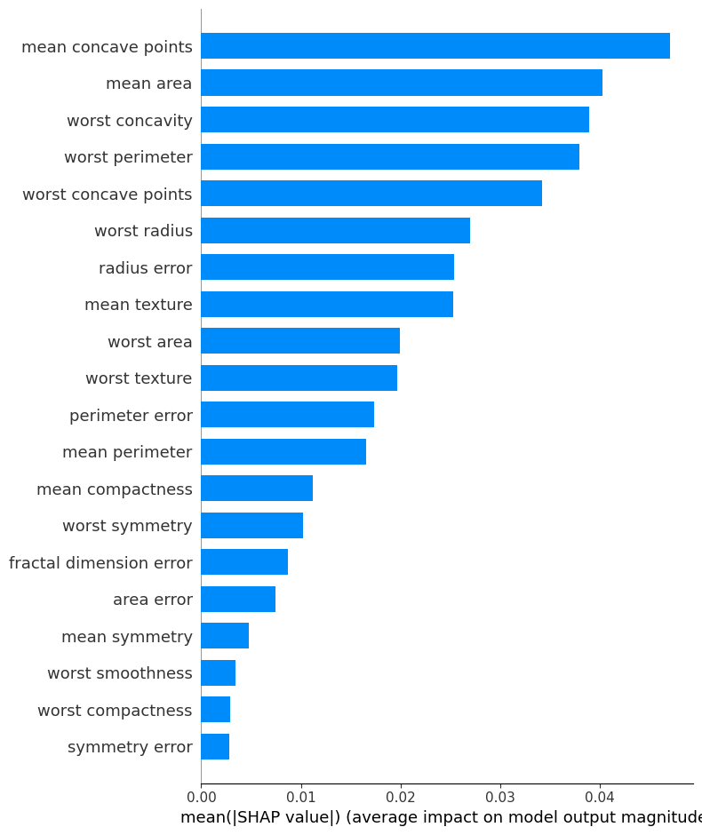

```
--- Model 3: Genel Etki Dağılımı (Summary Plot) ---
```

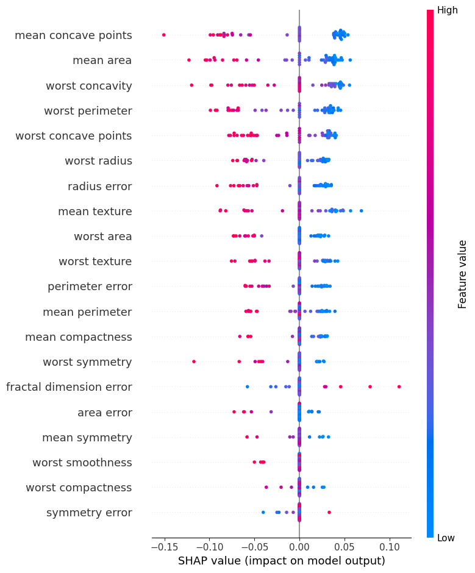

```
Optuna En İyi Modeli için SHAP değerleri hesaplanıyor...
```

```
SHAP çıktısı Array formatında. Şekil: (50, 30, 2)

--- Optuna Model: Genel Etki (Summary Plot - Dots) ---
```

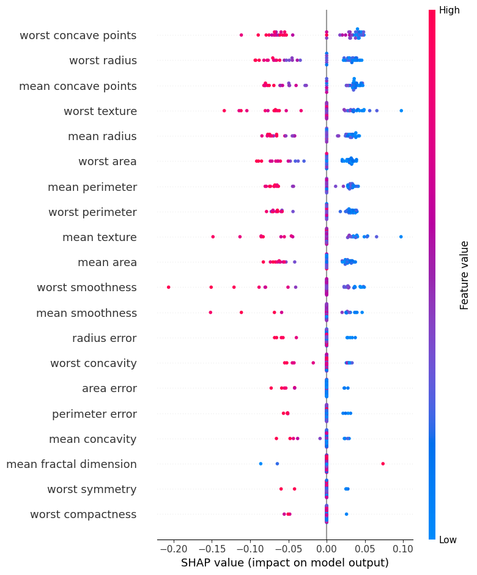

```
--- Optuna Model: Ortalama Etki (Bar Plot) ---
```

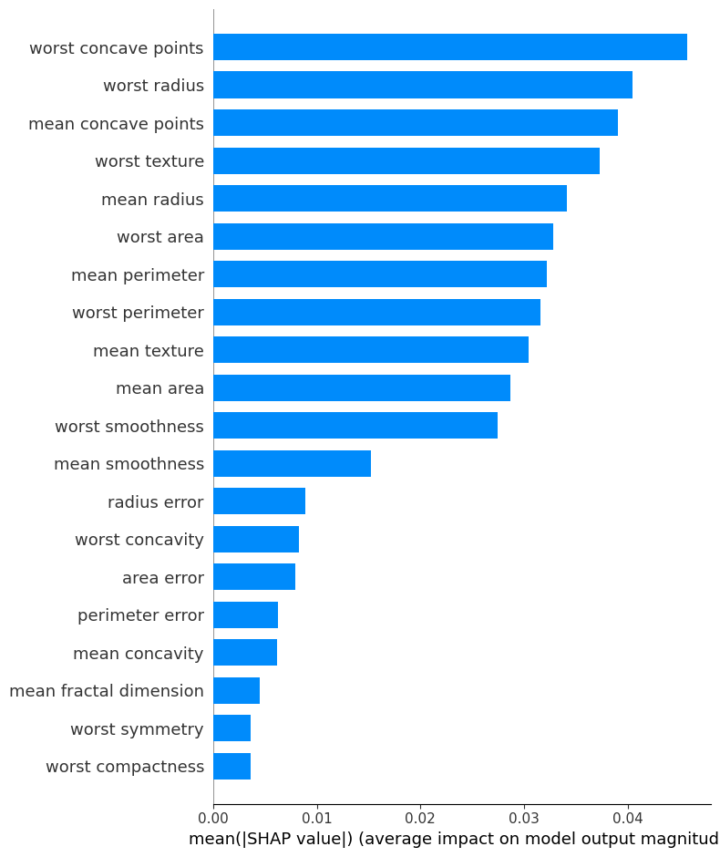

```
--- Optuna Model: Tekil Karar Açıklaması (Force Plot) ---
```

[figure not shown]

```
--- Optuna Model: Karar Yolu (Decision Plot) ---
```

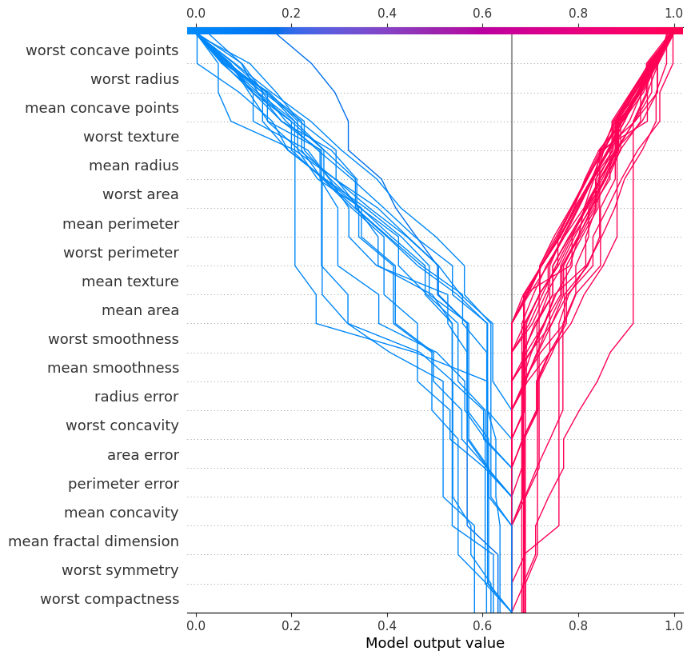

```python
# --- BÖLÜM 10: XAI - SHAP Açıklanabilirlik Analizi ---

# JavaScript görselleştirmelerini başlat
shap.initjs()

# SHAP hesaplaması MLP için yavaştır, hızlandırmak için veriyi özetliyoruz (K-Means)
# Tüm eğitim seti yerine 10 merkez nokta (centroid) kullanıyoruz.
X_train_summary = shap.kmeans(X_train, 10)

# 10.1 Manuel Seçilen En İyi Model (Model 3) İçin SHAP Analizi
print("Model 3 (Geniş) için SHAP değerleri hesaplanıyor...")

explainer_manual = shap.KernelExplainer(best_model.predict_proba, X_train_summary)

# Test setinden rastgele 50 örnek alıp açıklayalım
X_test_sample = X_test.sample(50, random_state=42)
shap_values_manual = explainer_manual.shap_values(X_test_sample)

# --- HATA DÜZELTME BLOĞU ---
# SHAP çıktısının formatını kontrol edip doğru matrisi seçiyoruz
def get_shap_values_for_plotting(shap_values, class_index=1):
    if isinstance(shap_values, list):
        # Eğer liste ise (örn: [class0_values, class1_values]), istenen sınıfı al
        print(f"SHAP çıktısı Liste formatında. Uzunluk: {len(shap_values)}")
        return shap_values[class_index]
    elif isinstance(shap_values, np.ndarray):
        # Eğer tek bir array ise
        print(f"SHAP çıktısı Array formatında. Şekil: {shap_values.shape}")
        if len(shap_values.shape) == 3: # (samples, features, classes)
            return shap_values[:, :, class_index]
        else: # (samples, features) -> Muhtemelen binary tek çıktı
            return shap_values
    else:
        return shap_values

# Doğru matrisi alıyoruz
shap_vals_to_plot = get_shap_values_for_plotting(shap_values_manual, class_index=1)

print(f"Plotlanacak Matris Boyutu: {shap_vals_to_plot.shape}")
print(f"Veri Seti Boyutu: {X_test_sample.shape}")
# ---------------------------

print("\n--- Model 3: Özellik Önem Sıralaması (Bar Plot) ---")
shap.summary_plot(shap_vals_to_plot, X_test_sample, plot_type="bar")

print("\n--- Model 3: Genel Etki Dağılımı (Summary Plot) ---")
shap.summary_plot(shap_vals_to_plot, X_test_sample)


# 10.2 Optuna En İyi Model İçin SHAP Analizi
print("Optuna En İyi Modeli için SHAP değerleri hesaplanıyor...")

explainer_optuna = shap.KernelExplainer(optuna_best_model.predict_proba, X_train_summary)
shap_values_optuna = explainer_optuna.shap_values(X_test_sample)

# Aynı düzeltmeyi Optuna modeli için de yapıyoruz
shap_vals_optuna_to_plot = get_shap_values_for_plotting(shap_values_optuna, class_index=1)

print("\n--- Optuna Model: Genel Etki (Summary Plot - Dots) ---")
shap.summary_plot(shap_vals_optuna_to_plot, X_test_sample)

print("\n--- Optuna Model: Ortalama Etki (Bar Plot) ---")
shap.summary_plot(shap_vals_optuna_to_plot, X_test_sample, plot_type="bar")

print("\n--- Optuna Model: Tekil Karar Açıklaması (Force Plot) ---")
# Force plot için expected_value da liste olabilir, onu da kontrol ediyoruz
expected_val = explainer_optuna.expected_value
if isinstance(expected_val, list) or isinstance(expected_val, np.ndarray):
    expected_val = expected_val[1] # Pozitif sınıf

shap.force_plot(
    expected_val,
    shap_vals_optuna_to_plot[0,:],
    X_test_sample.iloc[0,:],
    matplotlib=True
)
plt.show()

print("\n--- Optuna Model: Karar Yolu (Decision Plot) ---")
shap.decision_plot(
    expected_val,
    shap_vals_optuna_to_plot,
    X_test_sample.columns
)
```

### 10. Bölüm Değerlendirmesi: XAI ve SHAP Analizi

Bu bölümde, hem manuel olarak seçilen en iyi modelin (Model 3) hem de Optuna ile optimize edilen modelin karar mekanizmaları **SHAP (SHapley Additive exPlanations)** kütüphanesi ile incelenmiş ve yorumlanmıştır.

#### 10.3 Sonuçların Yorumlanması

Analizler sonucunda ödev kapsamında sorulan sorular şu şekilde yanıtlanmıştır:

**1. Hangi özellikler kararları belirledi?** Her iki model (Manuel ve Optuna) incelendiğinde, kanser teşhisinde belirleyici olan temel faktörlerin **hücre şekli bozuklukları** ve **hücre boyutu** olduğu görülmüştür.

- **İçbükeylik (Concavity/Concave Points):** Hücre çekirdeğindeki girintilerin sayısı ve derinliği en kritik belirteçtir.
- **Boyut (Area/Radius/Perimeter):** Tümörün kapladığı alan ve çevre uzunluğu, kararı doğrudan etkileyen ikinci en önemli faktördür.
- **Doku (Texture):** Hücre yüzeyinin pürüzlülüğü de (özellikle Optuna modelinde) karara katkı sağlamaktadır.

**2. Optuna’nın bulduğu model hangi özelliklere daha duyarlı?** Optuna ile optimize edilen model, manuel modelden farklı bir strateji geliştirerek **"Worst" (En Kötü/En Uç)** değerlere odaklanmıştır.

### Genel Sonuç

Optuna ile yapılan hiperparametre optimizasyonu sadece modelin başarımını (**%98.6 F1-Score**) artırmakla kalmamış, aynı zamanda modelin karar mekanizmasını tıbbi teşhis mantığına (en kötü huylu hücreyi baz alma) daha uygun hale getirmiştir. Bu durum, modelin güvenilirliğini artıran en önemli bulgudur.